# A First RMD File

Milo Schmitt

2023-11-07

## The Collatz Conjecture

The Collatz Conjecture presents two arithmetic operations and a question: if these two operators are applied, will we be able to transform any positive integer into the number 1?

Consider the following piecewise function:

[output not shown]

(The above was created in LateX, and I did not realize that it can only be used with an HTML document)

f(n) = { f(n/2) if n is even f(3n+1) if n is odd stop if n is one }

The number of times a positive integer n must be passed through this function to transform into one is known as the stopping time. For example, the stopping time of 1 is 0, 2 is 1, and 3 is 7.

The goal presented was to find a visualization to represent the first stopping numbers of the first 10,000 positive integers.

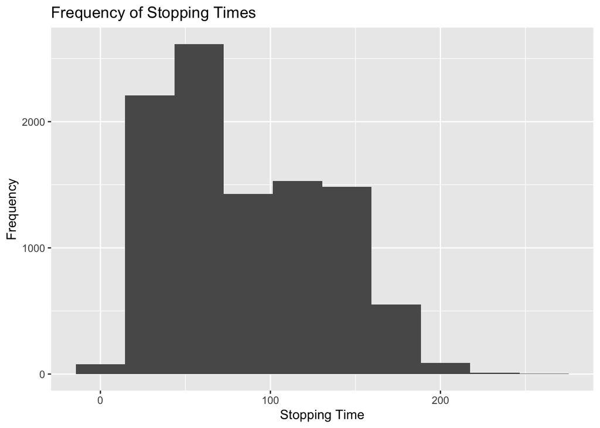

The above histogram displays one bar for a certain range of stopping times. For each of these ranges, the y axis represents the frequency at which the stopping time appears. It should be noted that a majority of the first 10,000 positive integers have stopping times between 0 and 100.

## Diamonds

The Diamonds dataset provided by R is a large dataset representing a group of diamonds. Each of these diamonds has many attributes: cut, color, price, length, width, height, and more. The goal of this activity is to create a visualization which displays a relationship between a certain diamond characteristic and the price of diamonds.

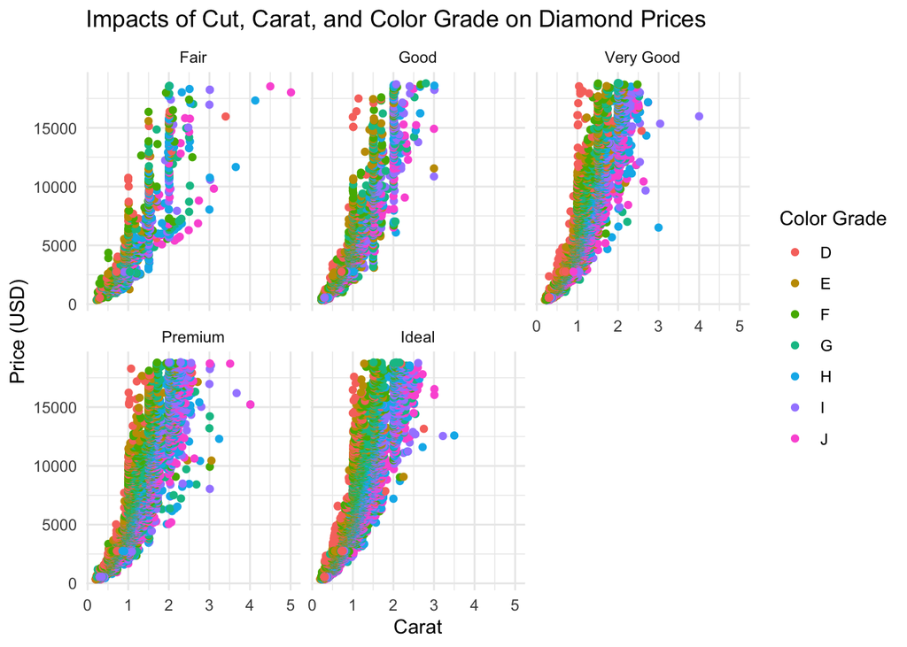

```
## # A tibble: 5 × 28
##   cut       x_count x_min  x_Q1 x_median  x_Q3 x_max x_mad x_mean  x_sd y_count
##   <ord>       <int> <dbl> <dbl>    <dbl> <dbl> <dbl> <dbl>  <dbl> <dbl>   <int>
## 1 Fair         1610     0  5.63     6.18  6.7  10.7  0.808   6.25 0.964    1610
## 2 Good         4906     0  5.02     5.98  6.42  9.44 1.10    5.84 1.06     4906
## 3 Very Good   12082     0  4.75     5.74  6.47 10.0  1.25    5.74 1.10    12082
## 4 Premium     13791     0  4.8      6.11  6.8  10.1  1.42    5.97 1.19    13791
## 5 Ideal       21551     0  4.54     5.25  6.44  9.65 1.19    5.51 1.06    21551
## # ℹ 17 more variables: y_min <dbl>, y_Q1 <dbl>, y_median <dbl>, y_Q3 <dbl>,
## #   y_max <dbl>, y_mad <dbl>, y_mean <dbl>, y_sd <dbl>, z_count <int>,
## #   z_min <dbl>, z_Q1 <dbl>, z_median <dbl>, z_Q3 <dbl>, z_max <dbl>,
## #   z_mad <dbl>, z_mean <dbl>, z_sd <dbl>
```

The above table is a summary of various statistics derived from the x, y, and z (length, width, height) values from the diamonds data set.

Cut and Color of Diamonds

| Color/Cut | Fair | Good | Very Good | Premium | Ideal | Total |
| --- | --- | --- | --- | --- | --- | --- |
| D | 163 (0.30%) | 662 (1.23%) | 1,513 (2.80%) | 1,603 (2.97%) | 2,834 (5.25%) | 6,775 (12.56%) |
| E | 224 (0.42%) | 933 (1.73%) | 2,400 (4.45%) | 2,337 (4.33%) | 3,903 (7.24%) | 9,797 (18.16%) |
| F | 312 (0.58%) | 909 (1.69%) | 2,164 (4.01%) | 2,331 (4.32%) | 3,826 (7.09%) | 9,542 (17.69%) |
| G | 314 (0.58%) | 871 (1.61%) | 2,299 (4.26%) | 2,924 (5.42%) | 4,884 (9.05%) | 11,292 (20.93%) |
| H | 303 (0.56%) | 702 (1.30%) | 1,824 (3.38%) | 2,360 (4.38%) | 3,115 (5.77%) | 8,304 (15.39%) |
| I | 175 (0.32%) | 522 (0.97%) | 1,204 (2.23%) | 1,428 (2.65%) | 2,093 (3.88%) | 5,422 (10.05%) |
| J | 119 (0.22%) | 307 (0.57%) | 678 (1.26%) | 808 (1.50%) | 896 (1.66%) | 2,808 (5.21%) |
| Total | 1,610 (2.98%) | 4,906 (9.10%) | 12,082 (22.40%) | 13,791 (25.57%) | 21,551 (39.95%) | 53,940 (100.00%) |

The above table displays frequencies of various attributes within the diamond table. It can be noted that a significant portion of the diamonds are of the premium or ideal quality.

## Reflections

The most significant lesson I’ve learned throughout this course is the ability to plan out and describe my code. Being able to present material in a meaningful and comprehensible manner is very important in all aspects of life, not just data science. I feel that I’ve also learned how to manipulate and visualize data frames, which is a useful skill to have.

One of my concerns is that data recovered from real-world activities is not always presented in a clean or enjoyable manner. While I have learned various data wrangling skills to account for this, I think I still need to polish these skills for the future.

# Code Appendix

```r
knitr::opts_chunk$set(echo = FALSE, message = FALSE, warning = FALSE)

#Load packages with groundhog to improve stability
library("groundhog")
pkgs <- c("ggplot2", "dplyr", "janitor", "kableExtra", "knitr")
groundhog.library(pkgs, '2023-11-07') #Use the date that you started the project here


updateEven <- function(number) # create function for evens
{
return(number/2)
}

updateOdd <- function(number) # create function for odds
{
return(number*3 + 1)
}

countCollatz <- function(number) # create final function
{
count = 0
result = 0
while(number != 1) # stop if number is one
{
if(number%%2 == 0)
{
result <- updateEven(number) # even function if # is even
count <- count + 1
}

else
{
result <- updateOdd(number) # odd function if not even
count <- count + 1
}
number = result
}
return(count)
}

inputs <- seq(1, 10000, 1) # input numbers from 1 to 10000
countCollatzVectorized <- Vectorize(countCollatz)
stopping_times <- countCollatzVectorized(inputs)
stopping_times <- as.data.frame(stopping_times) # turn vector into dataframe

ggplot(stopping_times, aes(x = stopping_times)) +
  geom_histogram(bins=10) + # 10 bins to prevent overcrowding
  labs( # set labels
    title = "Frequency of Stopping Times",
    x = "Stopping Time",
    y = "Frequency"
  )

ggplot(diamonds) + aes(x = carat, y = price, colour = color) + # x carat, y price, color by color grade

geom_point(shape = "circle", size = 1.5) + # scatter plot

labs( # more detailed labels

x = "Carat",

y = "Price (USD)",

color = "Color Grade",

title = "Impacts of Cut, Carat, and Color Grade on Diamond Prices"

) +

scale_color_hue(direction = 1) +

theme_minimal() +

facet_wrap(vars(cut)) # five graphs for cut
diamonds %>%
  group_by(cut) %>%
  summarise(
    across(c(x, y, z), list(
               count = ~sum(!is.na(.)),
               min = ~min(., na.rm = TRUE),
               Q1 = ~quantile(., probs = 0.25, na.rm = TRUE),
               median = ~median(., na.rm = TRUE),
               Q3 = ~quantile(., probs = 0.75, na.rm = TRUE),
               max = ~max(., na.rm = TRUE),
               mad = ~mad(., na.rm = TRUE),
               mean = ~mean(., na.rm = TRUE),
               sd = ~sd(., na.rm = TRUE)
  )))


diamondTable <- diamonds %>%
  tabyl(color, cut) %>%
  adorn_totals(where = c("row", "col")) %>%
  adorn_percentages(denominator = "all") %>%
  adorn_pct_formatting(digits = 2) %>%
  adorn_title(
    placement = "combined",
    row_name = "Color",
    col_name = "Cut")

formatNs <- attr(diamondTable, "core") %>%
  adorn_totals(where = c("row", "col")) %>%
  mutate(
    across(where(is.numeric), format, big.mark = ",")
  )

diamondFreqTab <- diamondTable %>%
  adorn_ns(position = "front", ns = formatNs)

diamondFreqTab %>%
  kable(
    caption = "Cut and Color of Diamonds",
    booktabs = TRUE,
    align = c('l', rep("c", 6))
  ) %>%
  kableExtra::kable_styling(
    bootstrap_options = c("striped", "condensed"),
    font_size = 16
  )
```